# Optimal Treatment Analysis

## Outcome Variable

**Outcome Variable:** haz

## Predictor Variables

**Intervention Variable:** exclfeed36

**Adjustment Set:**

- arm
- sex
- brthmon
- W_mage
- meducyrs
- feducyrs
- hhwealth_quart
- hfoodsec
- W_mhtcm
- W_mwtkg
- W_mbmi
- vagbrth
- W_gagebrth
- W_birthwt
- W_birthlen
- W_nrooms
- W_nchldlt5
- month
- W_parity
- impfloor
- impsan
- safeh20
- delta_W_mage
- delta_meducyrs
- delta_feducyrs
- delta_hhwealth_quart
- delta_hfoodsec
- delta_W_mhtcm
- delta_W_mwtkg
- delta_W_mbmi
- delta_vagbrth
- delta_W_gagebrth
- delta_W_birthwt
- delta_W_birthlen
- delta_W_nrooms
- delta_W_nchldlt5
- delta_month
- delta_W_parity
- delta_impfloor
- delta_impsan
- delta_safeh20

## Stratifying Variables

The analysis was stratified on these variable(s):

- agecat
- studyid
- country

## Data Summary

| agecat | studyid | country | exclfeed36 | n_cell | n |
| --- | --- | --- | --- | --- | --- |
| Birth | ki0047075b-MAL-ED | BANGLADESH | 1 | 32 | 221 |
| Birth | ki0047075b-MAL-ED | BANGLADESH | 0 | 189 | 221 |
| Birth | ki0047075b-MAL-ED | BRAZIL | 1 | 5 | 65 |
| Birth | ki0047075b-MAL-ED | BRAZIL | 0 | 60 | 65 |
| Birth | ki0047075b-MAL-ED | INDIA | 1 | 1 | 42 |
| Birth | ki0047075b-MAL-ED | INDIA | 0 | 41 | 42 |
| Birth | ki0047075b-MAL-ED | NEPAL | 1 | 0 | 26 |
| Birth | ki0047075b-MAL-ED | NEPAL | 0 | 26 | 26 |
| Birth | ki0047075b-MAL-ED | PERU | 1 | 5 | 223 |
| Birth | ki0047075b-MAL-ED | PERU | 0 | 218 | 223 |
| Birth | ki0047075b-MAL-ED | SOUTH AFRICA | 1 | 1 | 105 |
| Birth | ki0047075b-MAL-ED | SOUTH AFRICA | 0 | 104 | 105 |
| Birth | ki0047075b-MAL-ED | TANZANIA, UNITED REPUBLIC OF | 1 | 0 | 119 |
| Birth | ki0047075b-MAL-ED | TANZANIA, UNITED REPUBLIC OF | 0 | 119 | 119 |
| Birth | ki1000108-CMC-V-BCS-2002 | INDIA | 1 | 3 | 3 |
| Birth | ki1000108-CMC-V-BCS-2002 | INDIA | 0 | 0 | 3 |
| Birth | ki1000108-IRC | INDIA | 1 | 0 | 4 |
| Birth | ki1000108-IRC | INDIA | 0 | 4 | 4 |
| Birth | ki1000109-EE | PAKISTAN | 1 | 3 | 7 |
| Birth | ki1000109-EE | PAKISTAN | 0 | 4 | 7 |
| Birth | ki1017093b-PROVIDE | BANGLADESH | 1 | 119 | 490 |
| Birth | ki1017093b-PROVIDE | BANGLADESH | 0 | 371 | 490 |
| Birth | ki1101329-Keneba | GAMBIA | 1 | 363 | 1253 |
| Birth | ki1101329-Keneba | GAMBIA | 0 | 890 | 1253 |
| Birth | ki1113344-GMS-Nepal | NEPAL | 1 | 422 | 526 |
| Birth | ki1113344-GMS-Nepal | NEPAL | 0 | 104 | 526 |
| Birth | kiGH5241-JiVitA-3 | BANGLADESH | 1 | 8322 | 10681 |
| Birth | kiGH5241-JiVitA-3 | BANGLADESH | 0 | 2359 | 10681 |
| Birth | kiGH5241-JiVitA-4 | BANGLADESH | 1 | 1994 | 2517 |
| Birth | kiGH5241-JiVitA-4 | BANGLADESH | 0 | 523 | 2517 |

[output cut: 66 more lines]

The following strata were considered:

- agecat: 24 months, studyid: ki0047075b-MAL-ED, country: BANGLADESH
- agecat: 24 months, studyid: ki0047075b-MAL-ED, country: BRAZIL
- agecat: 24 months, studyid: ki0047075b-MAL-ED, country: INDIA
- agecat: 24 months, studyid: ki0047075b-MAL-ED, country: NEPAL
- agecat: 24 months, studyid: ki0047075b-MAL-ED, country: PERU
- agecat: 24 months, studyid: ki0047075b-MAL-ED, country: SOUTH AFRICA
- agecat: 24 months, studyid: ki0047075b-MAL-ED, country: TANZANIA, UNITED REPUBLIC OF
- agecat: 24 months, studyid: ki1000108-CMC-V-BCS-2002, country: INDIA
- agecat: 24 months, studyid: ki1000108-IRC, country: INDIA
- agecat: 24 months, studyid: ki1000109-EE, country: PAKISTAN
- agecat: 24 months, studyid: ki1017093b-PROVIDE, country: BANGLADESH
- agecat: 24 months, studyid: ki1101329-Keneba, country: GAMBIA
- agecat: 24 months, studyid: ki1113344-GMS-Nepal, country: NEPAL
- agecat: 24 months, studyid: ki1148112-LCNI-5, country: MALAWI
- agecat: 24 months, studyid: kiGH5241-JiVitA-3, country: BANGLADESH
- agecat: 24 months, studyid: kiGH5241-JiVitA-4, country: BANGLADESH
- agecat: 6 months, studyid: ki0047075b-MAL-ED, country: BANGLADESH
- agecat: 6 months, studyid: ki0047075b-MAL-ED, country: BRAZIL
- agecat: 6 months, studyid: ki0047075b-MAL-ED, country: INDIA
- agecat: 6 months, studyid: ki0047075b-MAL-ED, country: NEPAL
- agecat: 6 months, studyid: ki0047075b-MAL-ED, country: PERU
- agecat: 6 months, studyid: ki0047075b-MAL-ED, country: SOUTH AFRICA
- agecat: 6 months, studyid: ki0047075b-MAL-ED, country: TANZANIA, UNITED REPUBLIC OF
- agecat: 6 months, studyid: ki1000108-CMC-V-BCS-2002, country: INDIA
- agecat: 6 months, studyid: ki1000108-IRC, country: INDIA
- agecat: 6 months, studyid: ki1000109-EE, country: PAKISTAN
- agecat: 6 months, studyid: ki1000304b-SAS-FoodSuppl, country: INDIA
- agecat: 6 months, studyid: ki1017093b-PROVIDE, country: BANGLADESH
- agecat: 6 months, studyid: ki1101329-Keneba, country: GAMBIA
- agecat: 6 months, studyid: ki1113344-GMS-Nepal, country: NEPAL
- agecat: 6 months, studyid: ki1148112-LCNI-5, country: MALAWI
- agecat: 6 months, studyid: kiGH5241-JiVitA-3, country: BANGLADESH
- agecat: 6 months, studyid: kiGH5241-JiVitA-4, country: BANGLADESH
- agecat: Birth, studyid: ki0047075b-MAL-ED, country: BANGLADESH
- agecat: Birth, studyid: ki0047075b-MAL-ED, country: BRAZIL
- agecat: Birth, studyid: ki0047075b-MAL-ED, country: INDIA
- agecat: Birth, studyid: ki0047075b-MAL-ED, country: NEPAL
- agecat: Birth, studyid: ki0047075b-MAL-ED, country: PERU
- agecat: Birth, studyid: ki0047075b-MAL-ED, country: SOUTH AFRICA
- agecat: Birth, studyid: ki0047075b-MAL-ED, country: TANZANIA, UNITED REPUBLIC OF
- agecat: Birth, studyid: ki1000108-CMC-V-BCS-2002, country: INDIA
- agecat: Birth, studyid: ki1000108-IRC, country: INDIA
- agecat: Birth, studyid: ki1000109-EE, country: PAKISTAN
- agecat: Birth, studyid: ki1017093b-PROVIDE, country: BANGLADESH
- agecat: Birth, studyid: ki1101329-Keneba, country: GAMBIA
- agecat: Birth, studyid: ki1113344-GMS-Nepal, country: NEPAL
- agecat: Birth, studyid: kiGH5241-JiVitA-3, country: BANGLADESH
- agecat: Birth, studyid: kiGH5241-JiVitA-4, country: BANGLADESH

### Dropped Strata

Some strata were dropped due to rare outcomes:

- agecat: Birth, studyid: ki0047075b-MAL-ED, country: INDIA
- agecat: Birth, studyid: ki0047075b-MAL-ED, country: NEPAL
- agecat: Birth, studyid: ki0047075b-MAL-ED, country: SOUTH AFRICA
- agecat: Birth, studyid: ki0047075b-MAL-ED, country: TANZANIA, UNITED REPUBLIC OF
- agecat: Birth, studyid: ki1000108-CMC-V-BCS-2002, country: INDIA
- agecat: Birth, studyid: ki1000108-IRC, country: INDIA
- agecat: Birth, studyid: ki1000109-EE, country: PAKISTAN
- agecat: 6 months, studyid: ki0047075b-MAL-ED, country: NEPAL
- agecat: 6 months, studyid: ki0047075b-MAL-ED, country: SOUTH AFRICA
- agecat: 6 months, studyid: ki0047075b-MAL-ED, country: TANZANIA, UNITED REPUBLIC OF
- agecat: 6 months, studyid: ki1000108-CMC-V-BCS-2002, country: INDIA
- agecat: 6 months, studyid: ki1000108-IRC, country: INDIA
- agecat: 6 months, studyid: ki1000109-EE, country: PAKISTAN
- agecat: 6 months, studyid: ki1000304b-SAS-FoodSuppl, country: INDIA
- agecat: 24 months, studyid: ki0047075b-MAL-ED, country: NEPAL
- agecat: 24 months, studyid: ki0047075b-MAL-ED, country: PERU
- agecat: 24 months, studyid: ki0047075b-MAL-ED, country: SOUTH AFRICA
- agecat: 24 months, studyid: ki0047075b-MAL-ED, country: TANZANIA, UNITED REPUBLIC OF
- agecat: 24 months, studyid: ki1000108-CMC-V-BCS-2002, country: INDIA
- agecat: 24 months, studyid: ki1000108-IRC, country: INDIA
- agecat: 24 months, studyid: ki1000109-EE, country: PAKISTAN

## Methods Detail

We’re interested in the causal parameters $E[Y_a]$ for all values of $a \in \mathcal{A}$. These parameters represent the mean outcome if, possibly contrary to fact, we intervened to set all units to have $A=a$. Under the randomization and positivity assumptions, these are identified by the statistical parameters $\psi_a=E_W[E_{Y|A,W}(Y|A=a,W)]$. In addition, we’re interested in the mean of $Y$, $E[Y]$ under no intervention (the observed mean). We will estimate these parameters by using SuperLearner to fit the relevant likelihood factors – $E_{Y|A,W}(Y|A=a,W)$ and $p(A=a|W)$, and then updating our likelihood fit using a joint TMLE.

For unadjusted analyses ($W=\{\}$), initial likelihoods were estimated using Lrnr_glm to estimate the simple $E(Y|A)$ and Lrnr_mean to estimate $p(A)$. For adjusted analyses, a small library containing Lrnr_glmnet, Lrnr_xgboost, and Lrnr_mean was used.

Having estimated these parameters, we will then use the delta method to estimate relative risks and attributable risks relative to a prespecified baseline level of $A$.

# Results Detail

## Results Plots

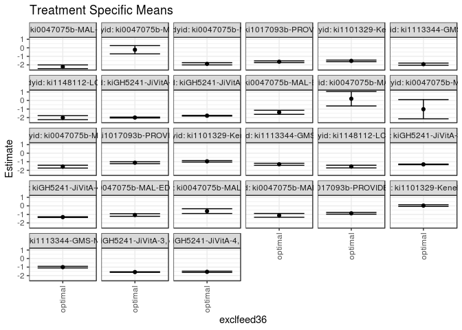

## Results Table

### Parameter: TSM

| agecat | studyid | country | intervention_level | baseline_level | estimate | ci_lower | ci_upper |
| --- | --- | --- | --- | --- | --- | --- | --- |
| Birth | ki0047075b-MAL-ED | BANGLADESH | optimal | observed | -1.0696417 | -1.2213202 | -0.9179633 |
| Birth | ki0047075b-MAL-ED | BRAZIL | optimal | observed | -0.6156058 | -0.8968173 | -0.3343943 |
| Birth | ki0047075b-MAL-ED | PERU | optimal | observed | -1.1149497 | -1.3362902 | -0.8936093 |
| Birth | ki1017093b-PROVIDE | BANGLADESH | optimal | observed | -0.8715956 | -0.9734447 | -0.7697465 |
| Birth | ki1101329-Keneba | GAMBIA | optimal | observed | 0.0323984 | -0.0635572 | 0.1283541 |
| Birth | ki1113344-GMS-Nepal | NEPAL | optimal | observed | -1.0055592 | -1.1022870 | -0.9088314 |
| Birth | kiGH5241-JiVitA-3 | BANGLADESH | optimal | observed | -1.5824372 | -1.6154916 | -1.5493829 |
| Birth | kiGH5241-JiVitA-4 | BANGLADESH | optimal | observed | -1.5543837 | -1.6298612 | -1.4789061 |
| 6 months | ki0047075b-MAL-ED | BANGLADESH | optimal | observed | -1.3824252 | -1.6218004 | -1.1430500 |
| 6 months | ki0047075b-MAL-ED | BRAZIL | optimal | observed | 0.2067433 | -0.6401101 | 1.0535968 |
| 6 months | ki0047075b-MAL-ED | INDIA | optimal | observed | -1.0194670 | -2.1448259 | 0.1058919 |
| 6 months | ki0047075b-MAL-ED | PERU | optimal | observed | -1.5771211 | -1.7438948 | -1.4103474 |
| 6 months | ki1017093b-PROVIDE | BANGLADESH | optimal | observed | -1.1163131 | -1.2276985 | -1.0049278 |
| 6 months | ki1101329-Keneba | GAMBIA | optimal | observed | -0.9549711 | -1.0429455 | -0.8669966 |
| 6 months | ki1113344-GMS-Nepal | NEPAL | optimal | observed | -1.3003037 | -1.4182735 | -1.1823339 |
| 6 months | ki1148112-LCNI-5 | MALAWI | optimal | observed | -1.5679753 | -1.7248164 | -1.4111343 |
| 6 months | kiGH5241-JiVitA-3 | BANGLADESH | optimal | observed | -1.3108915 | -1.3458930 | -1.2758900 |
| 6 months | kiGH5241-JiVitA-4 | BANGLADESH | optimal | observed | -1.3162517 | -1.3628587 | -1.2696446 |
| 24 months | ki0047075b-MAL-ED | BANGLADESH | optimal | observed | -2.2195161 | -2.4341179 | -2.0049143 |
| 24 months | ki0047075b-MAL-ED | BRAZIL | optimal | observed | -0.2269048 | -0.7114073 | 0.2575977 |
| 24 months | ki0047075b-MAL-ED | INDIA | optimal | observed | -1.8769384 | -2.0039249 | -1.7499518 |
| 24 months | ki1017093b-PROVIDE | BANGLADESH | optimal | observed | -1.6264571 | -1.7280123 | -1.5249020 |
| 24 months | ki1101329-Keneba | GAMBIA | optimal | observed | -1.5310562 | -1.6220279 | -1.4400846 |
| 24 months | ki1113344-GMS-Nepal | NEPAL | optimal | observed | -1.9181262 | -2.0484622 | -1.7877902 |
| 24 months | ki1148112-LCNI-5 | MALAWI | optimal | observed | -2.0103827 | -2.2442732 | -1.7764923 |
| 24 months | kiGH5241-JiVitA-3 | BANGLADESH | optimal | observed | -1.9970485 | -2.0501099 | -1.9439871 |
| 24 months | kiGH5241-JiVitA-4 | BANGLADESH | optimal | observed | -1.7801683 | -1.8232444 | -1.7370921 |

### Parameter: E(Y)

| agecat | studyid | country | intervention_level | baseline_level | estimate | ci_lower | ci_upper |
| --- | --- | --- | --- | --- | --- | --- | --- |
| Birth | ki0047075b-MAL-ED | BANGLADESH | observed | observed | -1.0802262 | -1.2151319 | -0.9453206 |
| Birth | ki0047075b-MAL-ED | BRAZIL | observed | observed | -0.6760000 | -0.9521457 | -0.3998543 |
| Birth | ki0047075b-MAL-ED | PERU | observed | observed | -0.8913004 | -1.0115814 | -0.7710195 |
| Birth | ki1017093b-PROVIDE | BANGLADESH | observed | observed | -0.8769592 | -0.9559693 | -0.7979491 |
| Birth | ki1101329-Keneba | GAMBIA | observed | observed | 0.0318156 | -0.0392907 | 0.1029220 |
| Birth | ki1113344-GMS-Nepal | NEPAL | observed | observed | -1.0299620 | -1.1192344 | -0.9406896 |
| Birth | kiGH5241-JiVitA-3 | BANGLADESH | observed | observed | -1.5762700 | -1.6018685 | -1.5506716 |
| Birth | kiGH5241-JiVitA-4 | BANGLADESH | observed | observed | -1.5234724 | -1.5733491 | -1.4735957 |
| 6 months | ki0047075b-MAL-ED | BANGLADESH | observed | observed | -1.2072639 | -1.3248889 | -1.0896388 |
| 6 months | ki0047075b-MAL-ED | BRAZIL | observed | observed | 0.0475758 | -0.0963508 | 0.1915023 |
| 6 months | ki0047075b-MAL-ED | INDIA | observed | observed | -1.2055794 | -1.3250712 | -1.0860876 |
| 6 months | ki0047075b-MAL-ED | PERU | observed | observed | -1.3230913 | -1.4314947 | -1.2146879 |
| 6 months | ki1017093b-PROVIDE | BANGLADESH | observed | observed | -1.0855583 | -1.1591292 | -1.0119875 |
| 6 months | ki1101329-Keneba | GAMBIA | observed | observed | -0.9355822 | -0.9858754 | -0.8852889 |
| 6 months | ki1113344-GMS-Nepal | NEPAL | observed | observed | -1.3337634 | -1.4135810 | -1.2539459 |
| 6 months | ki1148112-LCNI-5 | MALAWI | observed | observed | -1.6395956 | -1.7592633 | -1.5199278 |
| 6 months | kiGH5241-JiVitA-3 | BANGLADESH | observed | observed | -1.3152982 | -1.3444394 | -1.2861570 |
| 6 months | kiGH5241-JiVitA-4 | BANGLADESH | observed | observed | -1.3514886 | -1.3904044 | -1.3125729 |
| 24 months | ki0047075b-MAL-ED | BANGLADESH | observed | observed | -1.9783962 | -2.1050210 | -1.8517715 |
| 24 months | ki0047075b-MAL-ED | BRAZIL | observed | observed | 0.0061144 | -0.1625850 | 0.1748138 |
| 24 months | ki0047075b-MAL-ED | INDIA | observed | observed | -1.8906250 | -2.0165920 | -1.7646580 |
| 24 months | ki1017093b-PROVIDE | BANGLADESH | observed | observed | -1.6022704 | -1.6857342 | -1.5188065 |
| 24 months | ki1101329-Keneba | GAMBIA | observed | observed | -1.5981956 | -1.6534947 | -1.5428965 |
| 24 months | ki1113344-GMS-Nepal | NEPAL | observed | observed | -1.8830717 | -1.9710591 | -1.7950844 |
| 24 months | ki1148112-LCNI-5 | MALAWI | observed | observed | -1.9651323 | -2.1053230 | -1.8249415 |
| 24 months | kiGH5241-JiVitA-3 | BANGLADESH | observed | observed | -2.0071989 | -2.0453355 | -1.9690623 |
| 24 months | kiGH5241-JiVitA-4 | BANGLADESH | observed | observed | -1.7922845 | -1.8313538 | -1.7532153 |

### Parameter: PAR

| agecat | studyid | country | intervention_level | baseline_level | estimate | ci_lower | ci_upper |
| --- | --- | --- | --- | --- | --- | --- | --- |
| Birth | ki0047075b-MAL-ED | BANGLADESH | optimal | observed | -0.0105845 | -0.0560517 | 0.0348827 |
| Birth | ki0047075b-MAL-ED | BRAZIL | optimal | observed | -0.0603942 | -0.1549570 | 0.0341686 |
| Birth | ki0047075b-MAL-ED | PERU | optimal | observed | 0.2236493 | 0.0075750 | 0.4397236 |
| Birth | ki1017093b-PROVIDE | BANGLADESH | optimal | observed | -0.0053635 | -0.0634355 | 0.0527084 |
| Birth | ki1101329-Keneba | GAMBIA | optimal | observed | -0.0005828 | -0.0706310 | 0.0694654 |
| Birth | ki1113344-GMS-Nepal | NEPAL | optimal | observed | -0.0244028 | -0.0673481 | 0.0185426 |
| Birth | kiGH5241-JiVitA-3 | BANGLADESH | optimal | observed | 0.0061672 | -0.0140057 | 0.0263401 |
| Birth | kiGH5241-JiVitA-4 | BANGLADESH | optimal | observed | 0.0309113 | -0.0257067 | 0.0875292 |
| 6 months | ki0047075b-MAL-ED | BANGLADESH | optimal | observed | 0.1751613 | -0.0492620 | 0.3995845 |
| 6 months | ki0047075b-MAL-ED | BRAZIL | optimal | observed | -0.1591676 | -0.9747955 | 0.6564603 |
| 6 months | ki0047075b-MAL-ED | INDIA | optimal | observed | -0.1861124 | -1.2854375 | 0.9132127 |
| 6 months | ki0047075b-MAL-ED | PERU | optimal | observed | 0.2540298 | 0.1139752 | 0.3940844 |
| 6 months | ki1017093b-PROVIDE | BANGLADESH | optimal | observed | 0.0307548 | -0.0618168 | 0.1233264 |
| 6 months | ki1101329-Keneba | GAMBIA | optimal | observed | 0.0193889 | -0.0547908 | 0.0935686 |
| 6 months | ki1113344-GMS-Nepal | NEPAL | optimal | observed | -0.0334598 | -0.1254705 | 0.0585510 |
| 6 months | ki1148112-LCNI-5 | MALAWI | optimal | observed | -0.0716202 | -0.1879986 | 0.0447581 |
| 6 months | kiGH5241-JiVitA-3 | BANGLADESH | optimal | observed | -0.0044066 | -0.0228978 | 0.0140845 |
| 6 months | kiGH5241-JiVitA-4 | BANGLADESH | optimal | observed | -0.0352370 | -0.0657612 | -0.0047128 |
| 24 months | ki0047075b-MAL-ED | BANGLADESH | optimal | observed | 0.2411198 | 0.0521996 | 0.4300401 |
| 24 months | ki0047075b-MAL-ED | BRAZIL | optimal | observed | 0.2330192 | -0.2369799 | 0.7030182 |
| 24 months | ki0047075b-MAL-ED | INDIA | optimal | observed | -0.0136866 | -0.0460640 | 0.0186908 |
| 24 months | ki1017093b-PROVIDE | BANGLADESH | optimal | observed | 0.0241868 | -0.0300765 | 0.0784501 |
| 24 months | ki1101329-Keneba | GAMBIA | optimal | observed | -0.0671394 | -0.1448562 | 0.0105775 |
| 24 months | ki1113344-GMS-Nepal | NEPAL | optimal | observed | 0.0350545 | -0.0558353 | 0.1259443 |
| 24 months | ki1148112-LCNI-5 | MALAWI | optimal | observed | 0.0452505 | -0.1194122 | 0.2099131 |
| 24 months | kiGH5241-JiVitA-3 | BANGLADESH | optimal | observed | -0.0101504 | -0.0430288 | 0.0227280 |
| 24 months | kiGH5241-JiVitA-4 | BANGLADESH | optimal | observed | -0.0121162 | -0.0312195 | 0.0069870 |